# Report on 1st pilot of main task

Michael

3/29/2019

## Data collection and design

The experiment can be examined [here](https://michael-franke.github.io/misleading_with_underinfo/experiments/04_04_forced_choice/index.html).

## Data cleaning

We will first remove anyone who did not answer all the color blindness questions right.

```r
# check colorblindness
color_blindness_failures = filter(d, trial_type == "color_blindness_test") %>%
  select(prolific_id, correct, response) %>%
  mutate(correct = ifelse(correct == response,1,0)) %>%
  group_by(prolific_id) %>%
  summarize(mean_correct = mean(correct)) %>%
  filter(mean_correct < 1) %>%
  pull(prolific_id)

d = filter(d, ! prolific_id %in% color_blindness_failures)

message("Number of failures on color blindness test: ", length(color_blindness_failures))
```

```
## Number of failures on color blindness test: 6
```

No other data cleaning was carried out so far (e.g., in terms of comprehension checks or similar).

## Results

Participants were randomly assigned to cooperative/competitive conditions. From the remaining participants 16 were assigned to the competitive condition, 19 to the cooperative condition.

### Self-assessment performance rating

Here is how participants rated their own success, split by competitive vs cooperative condition:

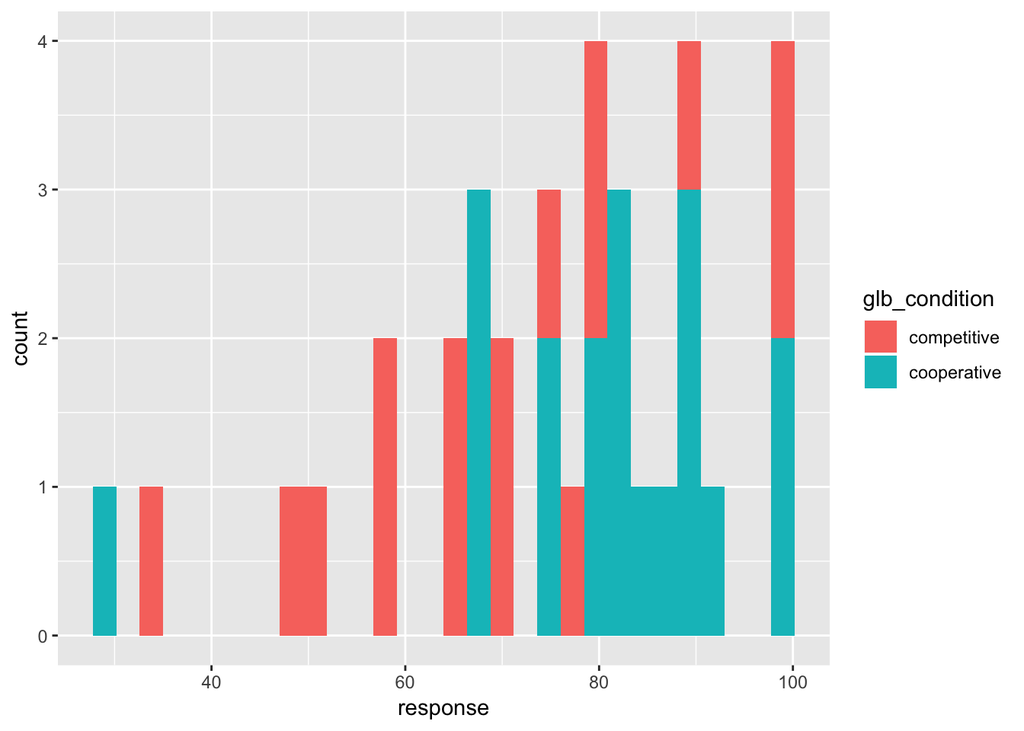

```r
filter(d, trial_type == "performance_rating") %>%
  mutate(response = as.numeric(response)) %>%
  ggplot(aes(x = response, fill = glb_condition)) + geom_histogram()
```

The mean performance rating for conditions are:

```r
filter(d, trial_type == "performance_rating") %>%
  mutate(response = as.numeric(response)) %>%
  group_by(glb_condition) %>%
  summarize(mean_rating = mean(response) %>% round(2))
```

```
## # A tibble: 2 x 2
##   glb_condition mean_rating
##   <chr>               <dbl>
## 1 competitive          70.2
## 2 cooperative          79.9
```

### Sentence completion task

Here are counts for the choices in the sentence completion task (the “interactive” card game). Remember that “pragmatic_bonus” is a choice of message that is uniquely referring to the bonus card when we take the implicature into account, while “pragmatic_noBonus” refers uniquely to the other card when we take the implicature into account.

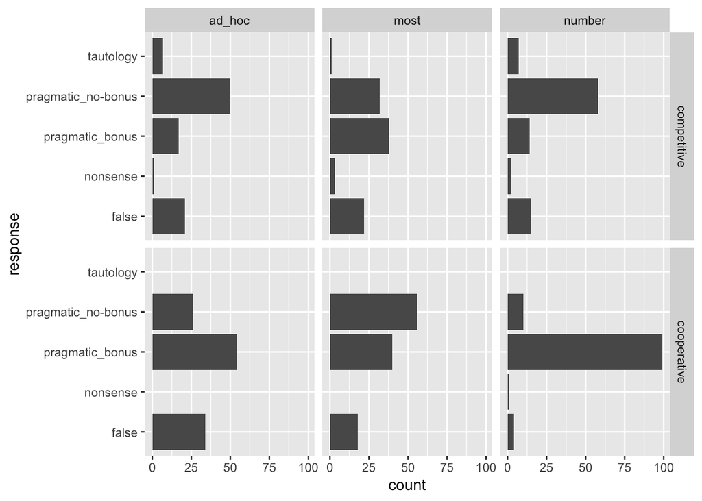

```r
filter(d, trial_type == "sentence_completion", ! condition %in% c("all", "none")) %>%
  select(prolific_id, condition, glb_condition, condition, response) %>%
  ggplot(aes(x = response)) + geom_bar() +
  facet_grid(glb_condition~condition) + coord_flip()
```

We would like to see a flip from preferred choice of “pragmatic_bonus” in the cooperative condition to a preferred choice of “pragmatic_noBonus” in the competitive condition. Unfortunately, we only see this in the /ad hoc/ and /number/ conditions, not in the /most/ condition, where we see at best a tendency to the reverse pattern.

### Truth value judgements

Here is the distribution of the proportion of semantic (true) to pragmatic (false) answers for each participant:

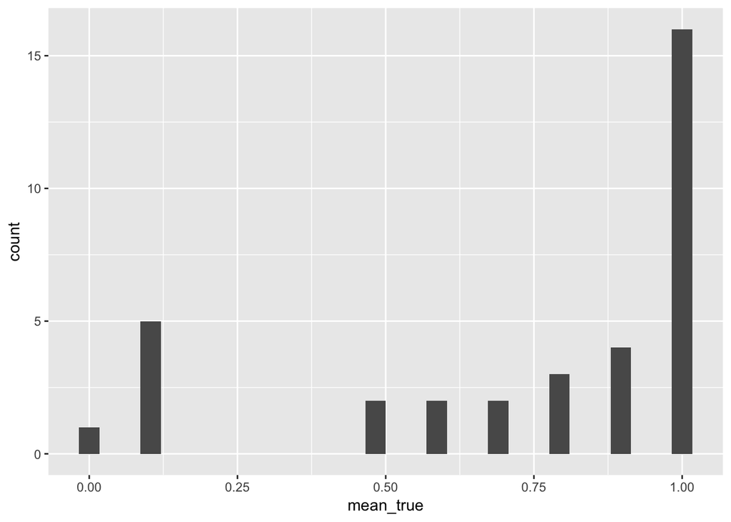

```r
d_tvj = filter(d, trial_type == "truth_value_judgements") %>%
  mutate(response = ifelse(response == "true", 1, 0))

d_summary_id = d_tvj %>% group_by(submission_id, trigger, condition) %>%
  summarize(mean_true = mean(response)) %>% arrange(submission_id) %>%
  filter(condition == "implicature")

d_summary_id_imp = d_summary_id %>% filter(trigger != "number") %>%
  group_by(submission_id) %>%
  summarize(mean_true = mean(mean_true))

d_summary_id_imp %>%
  ggplot(aes(x = mean_true)) + geom_histogram()
```

If we consider anyone with a mean proportion < .5 on /most/ and /ad hoc/ items a pragmatic respsonder we have 6 pragmatic responders.

### Sentence completion data from pragmatic responders

Looking only at the pragmatic responders, the counts for choices in the first sentence completion part are:

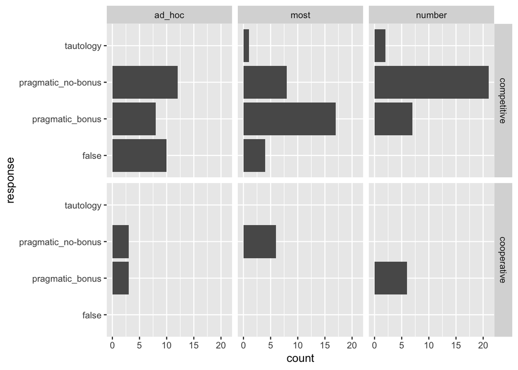

```r
filter(d, submission_id %in% (filter(d_summary_id_imp, mean_true < 0.5) %>% pull(submission_id ))) %>%
  filter(trial_type == "sentence_completion", ! condition %in% c("all", "none")) %>%
  select(prolific_id, condition, glb_condition, condition, response) %>%
  ggplot(aes(x = response)) + geom_bar() +
  facet_grid(glb_condition~condition) + coord_flip()
```

Interestingly, most pragmatic responders came from the competitive condition. It might be that this is causally relevant. Most importantly, however, the pragmatic responders in the competitive condition predominantly chose “pragmatic_bonus” to complete sentences with /most/.

I think we should reconsider the use of “most” and use “some” instead.